# Data Visualization: Day 2

Erik Westlund

2025-06-11

# Day 2: AI & LLMs, Data Preparation, and the Grammar of Graphics

## Overview For Day 2

- AI & LLMs: An Illustration
- Data preparation fundamentals
- Introduction to the grammar of graphics
- Colors & accessibility

## AI & LLMs: An Illustration

- We’ll use an LLM to help us prepare data for a visualization
- We’ll work with the `ai_example.qmd` file in the `examples` directory

# Data Preparation

## Getting Data Ready For Visualization

- Before we can do any visualization, we need to load in data and prepare it
- Take this step seriously, especially your variable names, as your code depends on it
- Workflow options:
  1. Clean up the data in a block at the top of your notebook
  2. Separate out the data preparation from the visualization code
- There are no universal answers to the best approach here; friction as you work often tells you what to do

## Option 1: Clean up the data in a block at the top of your notebook

#### Benefits

- Quick and straightforward
- All code in one place
- Easy for you and others to follow the workflow
- Good for exploratory analysis
- Minimal file management

#### Drawbacks

- Can become messy with large datasets
- Expensive transformations take time to run every time you run the notebook
- Harder to reuse code, especially in analyses with multiple steps
- Your colleagues may not care about the data preparation

## Option 2: Separate out the data preparation from the visualization code

- In this approach, you prepare the data in a separate script or notebook
- You can then load the data into your visualization notebook
- Two options:
  1. Run the data preparation script before running the visualization script
  2. Run the data preparation script as part of the visualization script
- Example of (1) above provided in our `examples/project-example` directory

## Benefits/Drawbacks of separating scripts

#### Benefits

- Data preparation notebook serves as documentation of your data
- Data preparation can be reused across projects
- Better separation of concerns
- Often asier to maintain and update

#### Drawbacks

- More files to manage
- Need to ensure data preparation is run in the right order
- Can be overkill for simple projects
- More complex project structure

## Saving Data To Load Later

- When using separate scripts, you’ll often want to save a copy of your cleaned data to load later scripts/notebooks
- A good option here is use the `saveRDS` function to save your data as an R data object
- This has a few benefits
  - RDS files maintain all R metadata
  - You can quickly load the data into R with `readRDS`, which can save you a lot of time when working with large datasets
  - RDS files are not easily to accidentally modify

## Preparing Data Example

- I have created an example of data preparation in the `examples/prams_1_data_prep.qmd` file
- Let’s load this up in RStudio and step through it.
- Note that we’ll be opening the entire course repo as a project, so the root directory is one level up from the `examples` directory
- We will return to this data file later to visualize it

# The Grammar of Graphics

## `ggplot2` and the Grammar of Graphics

- The “gg” in ggplot2 stands for the grammar of graphics, a concept coined by Leland Wilkinson and popularized by Hadley Wickham.
- Grammar in language is a set of rules for how language is structured.
- Grammar in graphics is a set of rules for how visual representations of data are structured.

## Key Concepts in ggplot2

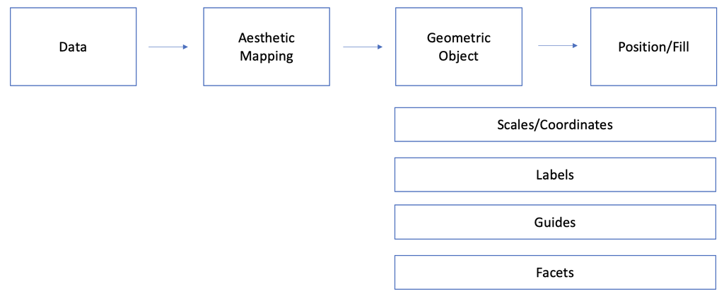

ggplot2 workflow

## `ggplot2` Workflow

1. Start with data
2. Pick an aesthetic mapping
3. Choose a geometric object
4. Add statistical transformations
5. Adjust finer details: scales, coordinate systems, faceting, etc.

## Aesthetic Mappings

- This is how your variables map onto the aesthetics of your figure
- It sounds highfalutin, but it usually just means:
  - What is your x?
  - What is your y?

## Geometric Objects (“geoms”)

- Geoms are the elements used to represent the data
- Geoms have associated stats/functions/statistical transformations
- Stats such as counts for groups often involve aggregations

## Geoms (cont.)

| Geom | R Function | Stat/Transformation | Use for |
| --- | --- | --- | --- |
| Point | `geom_point()` | Identity | Scatter plots |
| Bar | `geom_bar()` | Count | Bar plots |
| AB Line | `geom_abline()` | Slope | Line plots |
| Horizontal line | `geom_hline()` | Y intercept | Reference lines |
| Vertical line | `geom_vline()` | X intercept | Reference lines |
| Smoother | `geom_smooth()` | Smoothing function (GAM, Loess, etc.) | Showing patterns/trends |

## Position/Fill

- You can use position/fill to move elements around and color code geoms by aspects of the data, such as categories.
- For example, with a bar chart:
  - `stack`: Stack bars on top of each other
  - `fill`: Stack bars, but make them always fill up vertical space to 1
  - `dodge`: Put the bars next to each other
- Tip: When you reach for fill, always consider faceting in small multiples. The brain struggles with fills. More on this later.

## Aggregations

- To make a bar chart, one groups data and takes a mean, proportion, or count
- Software like ggplot will try to do this for you and it works well for simple cases
- This can fail with more difficult aggregations or when doing things like applying annotation labels
- A powerful and frustration-reducing technique is to do the aggregation yourself and then use the `identity` mapping
- This separates the statistical logic from the visual logic and is often what makes a tricky figure easier to make

# Examples

## Illustration: `ggplot2` Concepts

- Let’s load the `prams_2_ggplot_concepts.qmd` file
- In this file we will load the data we prepared in the previous file
- We will then work through the key ggplot2 concepts with examples.
- We will iterate on the figure to make it more informative and visually appealing

## Illustration: Iteration & Aggregation

- The PRAMS data we used comes pre-aggregated
- In `prams_3_iteration_aggregation.qmd` we will illustrate how statistical transformations work by showing:
  - The identity transformation with pre-aggregated data
  - Using aggregations with simulated data

We will also demonstrate the process of iterating on a figure to make it more informative and visually appealing.

# Colors & Accessibility

## Colors

- Colors are a powerful tool for communicating information
- They can be used to highlight important information and create a visual hierarchy

## RColorBrewer

- The `RColorBrewer` package gives good default color schemes that are accessible (i.e., easy to read for everyone) and aesthetically pleasing.
- `ggplot` by default picks out pleasing colors that are distinguishable from each other by the human eye.

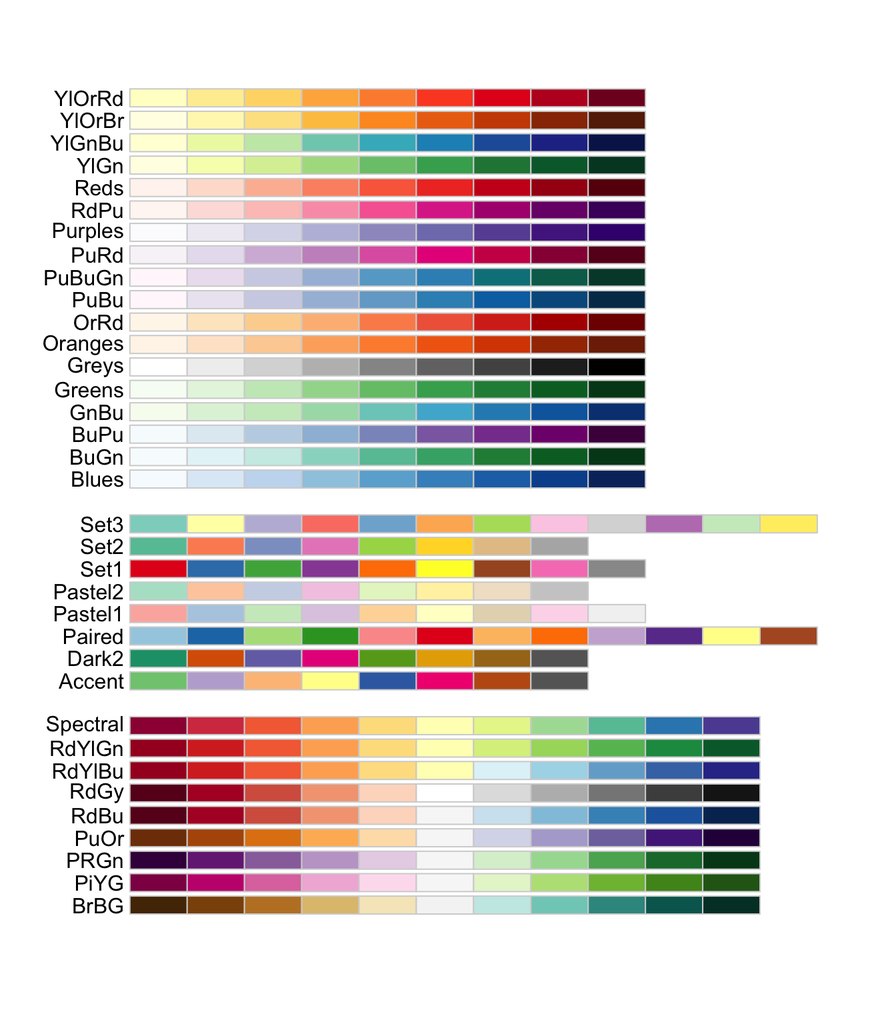

Accessible color swatches

## Using a Color Design System

- A design system is a set of rules for how to create a consistent visual language
- If you are really polishing a figure, you might want to use a color design system
- To the right is an example drawn from the `colors.R` file in the `examples` directory, which implements [TailwindCSS’s color palette](https://tailwindcss.com/docs/customizing-colors)

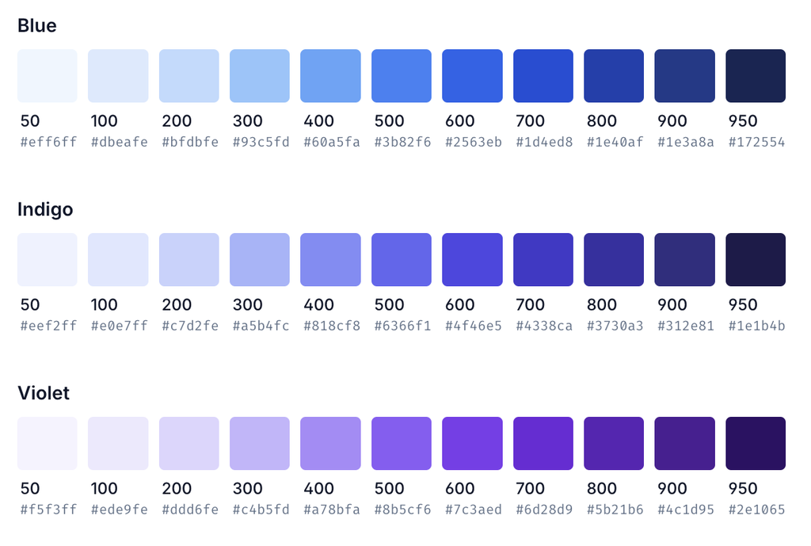

Tailwind Color Palette

## Example

- In the `examples/colors_and_accessibility.qmd` file, we will explore the use of color design systems and perceptually uniform colors